# aa_pathogens

Kimberly Ledger

2/17/2022

# *Amblyomma americanum* pathogen analyses

This code will explore the pathogens *Amblyomma americanum* collected in Alachua Co.

Load libraries

```r
library(tidyverse)
library(ggplot2)
library(lattice)
library(lme4)
library(MuMIn)
#library(car)
#library(MASS)
#library(stargazer)
#library(effects)
```

## Part 1: Prepare the data

Read in raw Alachua County Tick Data

```r
ticks <- read.csv("AlachuaTicksAllSites.csv")
str(ticks)
```

```
## 'data.frame':    1825 obs. of  15 variables:
##  $ Sample_Code      : chr  "HW_3May21_AA_A" "HW_13Apr21_IS" "29RD_12Mar21_AA_A" "29RD_12Mar21_AA_B" ...
##  $ Collection_Sample: chr  "AA1007" "IS83" "AA144" "AA145" ...
##  $ Collection_Box   : chr  "AAB13" "IXB2" "AAB2" "AAB2" ...
##  $ gDNA_Sample      : chr  "NymAA103" "IS83" "NymAA104" "NymAA105" ...
##  $ gDNA_Box         : chr  "NymAADNAB1Nat" "ISgDNAB1" "NymAADNAB1Nat" "NymAADNAB1Nat" ...
##  $ Field_Type       : chr  "Natural" "Natural" "Natural" "Natural" ...
##  $ Site             : chr  "Harmonic Woods" "Harmonic Woods" "29th Rd" "29th Rd" ...
##  $ Site_ID          : chr  "HW" "HW" "29RD" "29RD" ...
##  $ Visit            : int  9 7 5 5 7 9 9 12 9 10 ...
##  $ Date             : chr  "5/3/21" "4/13/21" "3/12/21" "3/12/21" ...
##  $ Tick_No_Tube     : int  1 1 1 1 1 1 1 1 1 1 ...
##  $ Species          : chr  "AA" "IS" "AA" "AA" ...
##  $ Lifestage        : chr  "N" "A" "N" "N" ...
##  $ Sex              : chr  NA "M" NA NA ...
##  $ Collection_Method: chr  "Flagging" "Dragging" "Dragging" "Dragging" ...
```

Read in raw Pathogen Data

```r
pathogen <- read.csv("AlCo_Pathogens.csv")
str(pathogen)
```

```
## 'data.frame':    1187 obs. of  20 variables:
##  $ Collection_Sample          : chr  "AM01" "AM02" "DV01" "DV02" ...
##  $ gDNA_Sample                : chr  "AM01" "AM02" "DV01" "DV02" ...
##  $ Babesia_sp                 : int  0 0 0 0 0 0 0 0 0 0 ...
##  $ Babesia_sp_Coco            : int  0 0 0 0 0 0 0 0 0 0 ...
##  $ Babesia_odocoieli          : int  0 0 0 0 0 0 0 0 0 0 ...
##  $ Borrelia_lonestari         : int  0 0 0 0 0 0 0 0 0 0 ...
##  $ Cryptoplasma_sp            : int  0 0 0 0 0 0 0 0 0 0 ...
##  $ Cytauxozoon_felis          : int  0 0 0 0 0 0 0 0 0 0 ...
##  $ Ehrlichia_chaffeensis      : int  0 0 0 0 0 0 0 0 0 0 ...
##  $ Ehrlichia_ewingii          : int  0 0 0 0 0 0 0 0 0 0 ...
##  $ Ehrlichia_sp_PanolaMountain: int  0 0 0 0 0 0 0 0 0 0 ...
##  $ Hepatozoon_sp_A            : int  0 0 0 0 0 0 0 0 0 0 ...
##  $ Hepatozoon_sp_B            : int  0 0 0 0 0 0 0 0 0 0 ...
##  $ Rickettsia_amblyommatis    : int  0 0 0 0 0 0 0 0 0 0 ...
##  $ Rickettsia_andeanae        : int  1 0 0 0 0 0 0 0 0 0 ...
##  $ Rickettsia_parkeri         : int  0 0 0 0 0 0 0 0 0 0 ...
##  $ Rickettsia_rhiphicephali   : int  0 0 0 0 0 0 1 0 0 0 ...
##  $ Rickettsia_sp_Iaff         : int  0 0 0 0 0 0 0 0 0 0 ...
##  $ Rickettsia_sp_Iscap        : int  0 0 0 0 0 0 0 0 0 0 ...
##  $ Theileria_cervi            : int  0 0 0 0 0 0 0 0 0 0 ...
```

Join pathogen results with the raw tick data by the gDNA_Sample and Collection_Sample identities

```r
data <- ticks %>%
  dplyr::left_join(pathogen, by = c("gDNA_Sample", "Collection_Sample"))

#data <- ticks %>%
#  dplyr::left_join(pathogen, by = c("Collection_Sample"))

head(data)
```

```
##         Sample_Code Collection_Sample Collection_Box gDNA_Sample      gDNA_Box
## 1    HW_3May21_AA_A            AA1007          AAB13    NymAA103 NymAADNAB1Nat
## 2     HW_13Apr21_IS              IS83           IXB2        IS83      ISgDNAB1
## 3 29RD_12Mar21_AA_A             AA144           AAB2    NymAA104 NymAADNAB1Nat
## 4 29RD_12Mar21_AA_B             AA145           AAB2    NymAA105 NymAADNAB1Nat
## 5   29RD_20Apr21_AA             AA639           AAB8    NymAA106 NymAADNAB1Nat
## 6 29RD_17May21_AA_A            AA1238          AAB16    NymAA107 NymAADNAB1Nat
##   Field_Type           Site Site_ID Visit    Date Tick_No_Tube Species
## 1    Natural Harmonic Woods      HW     9  5/3/21            1      AA
## 2    Natural Harmonic Woods      HW     7 4/13/21            1      IS
## 3    Natural        29th Rd    29RD     5 3/12/21            1      AA
## 4    Natural        29th Rd    29RD     5 3/12/21            1      AA
## 5    Natural        29th Rd    29RD     7 4/20/21            1      AA
## 6    Natural        29th Rd    29RD     9 5/17/21            1      AA
##   Lifestage  Sex Collection_Method Babesia_sp Babesia_sp_Coco Babesia_odocoieli
```

[output cut: 41 more lines]

for now there are NA’s in the data for any tick sample that was not processed in the lab

verify the data was joined correctly….

```r
tc <- data %>%
  filter(Theileria_cervi== 1)
```

all good to go except for something is off with Rickettsia amblyommatis.. this data only shows 563 positive but the original spreadsheet indicates 583 positive… moving on for now but will need to fix if we want to run any analyses on R.amblyommatis later

Make a summary table of microorganisms detected in each tick species

```r
data %>%
  dplyr::select(-c(Visit, Tick_No_Tube)) %>%
  group_by(Species) %>%
  dplyr::summarise(across(where(is.integer), sum, na.rm = TRUE))
```

```
## # A tibble: 6 × 19
##   Species Babesia_sp Babesia_sp_Coco Babesia_odocoieli Borrelia_lonestari
##   <chr>        <int>           <int>             <int>              <int>
## 1 AA              16               7                 0                 14
## 2 AM               0               0                 0                  0
## 3 DV               0               0                 0                  0
## 4 HAE              0               0                 0                  0
## 5 IA               0               0                 0                  0
## 6 IS               0               0                 8                  0
## # … with 14 more variables: Cryptoplasma_sp <int>, Cytauxozoon_felis <int>,
## #   Ehrlichia_chaffeensis <int>, Ehrlichia_ewingii <int>,
## #   Ehrlichia_sp_PanolaMountain <int>, Hepatozoon_sp_A <int>,
## #   Hepatozoon_sp_B <int>, Rickettsia_amblyommatis <int>,
## #   Rickettsia_andeanae <int>, Rickettsia_parkeri <int>,
## #   Rickettsia_rhiphicephali <int>, Rickettsia_sp_Iaff <int>,
## #   Rickettsia_sp_Iscap <int>, Theileria_cervi <int>
```

Okay, what PATHOGENIC microorganisms to humans or domestic animals are presest in *A. americanum*

Now i want to separate out just the *Amblyomma americanum* to look at…

```r
aa <- data %>%
  filter(Species == "AA") %>%
  mutate_all(na_if, "")
head(aa)
```

```
##         Sample_Code Collection_Sample Collection_Box gDNA_Sample      gDNA_Box
## 1    HW_3May21_AA_A            AA1007          AAB13    NymAA103 NymAADNAB1Nat
## 2 29RD_12Mar21_AA_A             AA144           AAB2    NymAA104 NymAADNAB1Nat
## 3 29RD_12Mar21_AA_B             AA145           AAB2    NymAA105 NymAADNAB1Nat
## 4   29RD_20Apr21_AA             AA639           AAB8    NymAA106 NymAADNAB1Nat
## 5 29RD_17May21_AA_A            AA1238          AAB16    NymAA107 NymAADNAB1Nat
## 6 29RD_17May21_AA_B            AA1239          AAB16    NymAA108 NymAADNAB1Nat
##   Field_Type           Site Site_ID Visit    Date Tick_No_Tube Species
## 1    Natural Harmonic Woods      HW     9  5/3/21            1      AA
## 2    Natural        29th Rd    29RD     5 3/12/21            1      AA
## 3    Natural        29th Rd    29RD     5 3/12/21            1      AA
## 4    Natural        29th Rd    29RD     7 4/20/21            1      AA
## 5    Natural        29th Rd    29RD     9 5/17/21            1      AA
## 6    Natural        29th Rd    29RD     9 5/17/21            1      AA
##   Lifestage  Sex Collection_Method Babesia_sp Babesia_sp_Coco Babesia_odocoieli
```

[output cut: 41 more lines]

Read in the covariate data for all 18 sites This site contains information on if the environment type was manicured or natural, and the forest, PC1 and PC2 landscape buffers

```r
covar <- read.csv("AlCo_SitesCovariates.csv")  ## 18 sites
head(covar)
```

```
##                 Site Site_ID  Easting Northing Field_Type Forest250m Forest500m
## 1       Reserve Park      RP 373075.5  3281598  Manicured  0.0000000  0.0259972
## 2 University Gardens      UG 368561.7  3280166  Manicured  0.4059153  0.2280836
## 3      Hogtown Creek      HT 370033.7  3285928  Manicured  0.6793893  0.4689848
## 4 Possum Creek Park       PC 365990.0  3286586  Manicured  0.4842319  0.3245446
## 5     Fred Cone Park      FC 375389.6  3280603  Manicured  0.1525510  0.4584023
## 6  Green Acres Park       GA 366138.7  3280294  Manicured  0.6352041  0.5656334
##     Forest1km  Forest2km Forest3km Forest4km   PC1_250m    PC2_250m   PC1_500m
## 1 0.009046603 0.04787764 0.1523864 0.2497138  3.0888399  1.25403665 -2.2285643
## 2 0.132940615 0.15290895 0.1432444 0.1541731  1.1042450 -2.71890707 -1.6918854
## 3 0.174897316 0.24949040 0.2753919 0.3340898 -0.4720229  0.26182597 -0.1811466
## 4 0.317132210 0.17751376 0.2416931 0.2822197  0.5823618  0.03426844 -0.8718743
## 5 0.415052873 0.40032172 0.4285704 0.4357618  1.0914845 -0.03089397  0.7046526
## 6 0.459594672 0.26329957 0.2377961 0.2197173 -0.2358455  0.56020279  0.3665116
##      PC2_500m    PC1_1km     PC2_1km    PC1_2km     PC2_2km    PC1_3km
## 1  1.14772157 -2.2237817  0.83389005 -2.2345973  0.29634256 -1.6579262
## 2 -4.17393010 -1.9912260 -1.90230643 -1.8760657 -0.08449422 -1.8529678
## 3  0.15115773 -1.4013427  0.04034195 -0.8045536 -0.19268275 -0.5241398
## 4  0.05922524 -0.5187457  0.44283357 -0.8368180 -0.25976343 -0.4419081
## 5  0.75143021  0.2710480 -0.96944716  0.2085390  0.28946092  0.2753296
## 6  0.53614632  0.5772039  0.23898928 -1.2213185  0.06781415 -1.5203214
##       PC2_3km    PC1_4km     PC2_4km
## 1  0.21477736 -1.7101280 -0.04952885
## 2 -0.29752137 -1.8570855 -0.11805117
## 3  0.06247605 -0.1973380  0.09175826
## 4  0.11303452 -0.2691747  0.27311929
## 5  0.36739258 -0.2885019  0.31535917
## 6 -0.17733426 -1.3869067 -0.04092310
```

create columns that indicate the presence or absence of the pathogens/pathogen groups of interest for *Amblyomma americanum*

- all human and domestic animal pathogens
- all human and domestic animal Ehrlichia sp.
- *Theileria cervi* - will not be included in this manuscript but could be interesting for something later on…

```r
aa_join <- aa %>%
  filter(!is.na(gDNA_Sample)) %>%
  dplyr::select(Site_ID, Babesia_sp_Coco, Babesia_odocoieli, Cytauxozoon_felis, Ehrlichia_chaffeensis, Ehrlichia_ewingii, Ehrlichia_sp_PanolaMountain, Rickettsia_parkeri, Theileria_cervi) %>%
  mutate(zoo_path = Babesia_sp_Coco + Babesia_odocoieli + Cytauxozoon_felis + Ehrlichia_chaffeensis + Ehrlichia_ewingii + Ehrlichia_sp_PanolaMountain + Rickettsia_parkeri) %>%
  mutate(zoo_ehr = Ehrlichia_chaffeensis + Ehrlichia_ewingii + Ehrlichia_sp_PanolaMountain) %>%
  dplyr::select(Site_ID, zoo_path, zoo_ehr, Theileria_cervi) %>%
  dplyr::left_join(covar, by = "Site_ID")

aa_join$zoo_path[aa_join$zoo_path > 0] <- 1  ## set coinfections to 1
aa_join$zoo_ehr[aa_join$zoo_ehr > 0] <- 1  ## set coinfections to 1

head(aa_join)
```

```
##   Site_ID zoo_path zoo_ehr Theileria_cervi                  Site  Easting
## 1      HW        0       0               0        Harmonic Woods 368535.6
## 2    29RD        0       0               0 29th Road Nature Park 370183.1
## 3    29RD        0       0               0 29th Road Nature Park 370183.1
## 4    29RD        0       0               0 29th Road Nature Park 370183.1
## 5    29RD        0       0               0 29th Road Nature Park 370183.1
## 6    29RD        0       0               0 29th Road Nature Park 370183.1
##   Northing Field_Type Forest250m Forest500m Forest1km  Forest2km Forest3km
## 1  3280276    Natural  0.2897149  0.1923322 0.1306786 0.15438460 0.1441753
## 2  3284095    Natural  0.3384302  0.1768603 0.1068676 0.09515316 0.1368760
## 3  3284095    Natural  0.3384302  0.1768603 0.1068676 0.09515316 0.1368760
## 4  3284095    Natural  0.3384302  0.1768603 0.1068676 0.09515316 0.1368760
## 5  3284095    Natural  0.3384302  0.1768603 0.1068676 0.09515316 0.1368760
## 6  3284095    Natural  0.3384302  0.1768603 0.1068676 0.09515316 0.1368760
##   Forest4km PC1_250m    PC2_250m  PC1_500m   PC2_500m   PC1_1km    PC2_1km
## 1 0.1491448 1.665890 -2.06852807 -1.906240 -3.5269699 -2.061078 -1.8918961
## 2 0.1743336 1.425794 -0.01235491 -1.673928  0.2358977 -1.615585  0.7510463
## 3 0.1743336 1.425794 -0.01235491 -1.673928  0.2358977 -1.615585  0.7510463
## 4 0.1743336 1.425794 -0.01235491 -1.673928  0.2358977 -1.615585  0.7510463
## 5 0.1743336 1.425794 -0.01235491 -1.673928  0.2358977 -1.615585  0.7510463
## 6 0.1743336 1.425794 -0.01235491 -1.673928  0.2358977 -1.615585  0.7510463
##     PC1_2km   PC2_2km   PC1_3km    PC2_3km   PC1_4km    PC2_4km
## 1 -1.906823 0.0000429 -1.849214 -0.2528462 -1.891990 -0.1183059
## 2 -1.767263 0.3386170 -1.391903  0.3296148 -1.619184  0.1619210
## 3 -1.767263 0.3386170 -1.391903  0.3296148 -1.619184  0.1619210
## 4 -1.767263 0.3386170 -1.391903  0.3296148 -1.619184  0.1619210
## 5 -1.767263 0.3386170 -1.391903  0.3296148 -1.619184  0.1619210
## 6 -1.767263 0.3386170 -1.391903  0.3296148 -1.619184  0.1619210
```

now let’s plot the relationship of pres/absence of pathogens with PC1

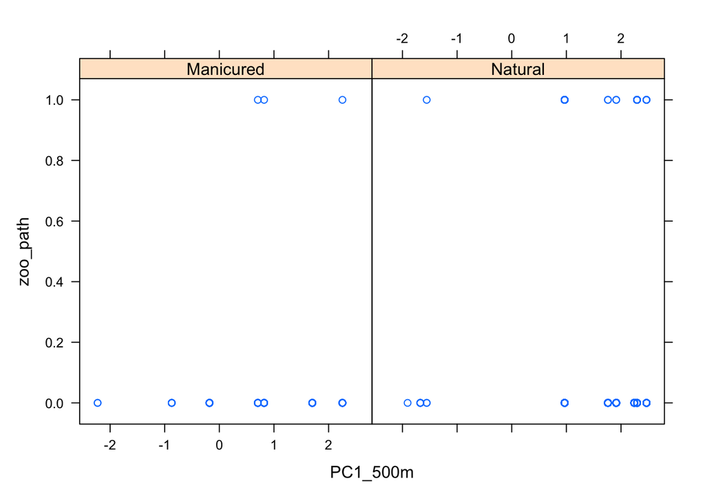

```r
#plot(x=aa_join$PC1_500m, y=aa_join$zoo_path)
xyplot(zoo_path ~ PC1_500m | Field_Type,
       data = aa_join)
```

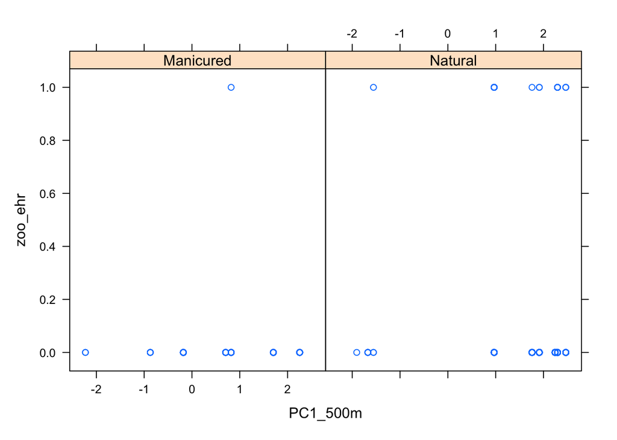

```r
#plot(x=aa_join$PC1_500m, y=aa_join$zoo_ehr)
xyplot(zoo_ehr ~ PC1_500m | Field_Type,
       data = aa_join)
```

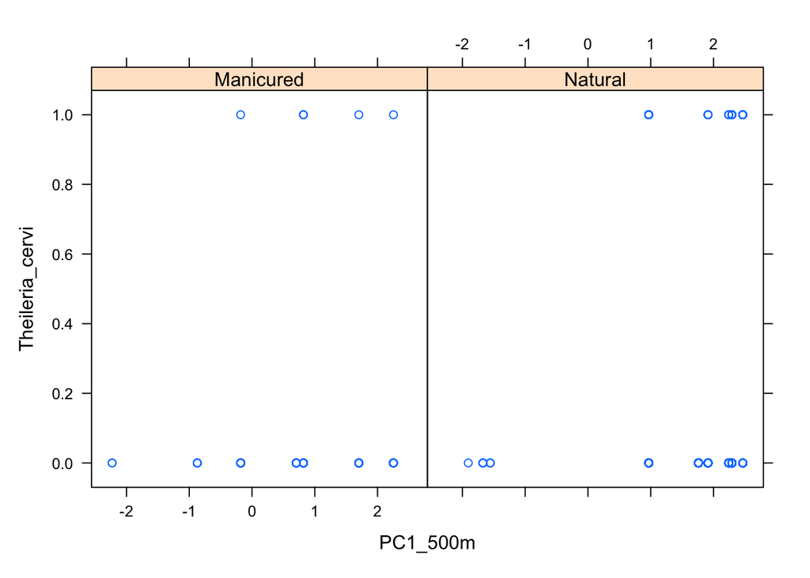

```r
#plot(x=aa_join$PC1_500m, y=aa_join$Theileria_cervi)
xyplot(Theileria_cervi~ PC1_500m | Field_Type,
       data = aa_join)
```

#### model presence/absence of any zoonotic pathogen at the individual level

try out mixed-effects GLM w/ binomial distribution - using Site ID as a random effect

```r
B0 <- glmer(zoo_path ~ 1 + (1|Site_ID), family = binomial, data = aa_join)
B1 <- glmer(zoo_path ~ Field_Type + (1|Site_ID), family = binomial, data = aa_join)
B2 <- glmer(zoo_path ~ PC1_500m + (1|Site_ID), family = binomial, data = aa_join)
B3 <- glmer(zoo_path ~ PC1_500m + Field_Type + (1|Site_ID), family = binomial, data = aa_join)
B4 <- glmer(zoo_path ~ PC1_500m * Field_Type + (1|Site_ID), family = binomial, data = aa_join)

AICc(B0,B1,B2,B3,B4)
```

```
##    df     AICc
## B0  2 302.0880
## B1  3 303.6858
## B2  3 303.1732
## B3  4 303.2643
## B4  5 302.6562
```

null model is as good or better than others

```r
summary(B4)
```

```
## Generalized linear mixed model fit by maximum likelihood (Laplace
##   Approximation) [glmerMod]
##  Family: binomial  ( logit )
## Formula: zoo_path ~ PC1_500m * Field_Type + (1 | Site_ID)
##    Data: aa_join
##
##      AIC      BIC   logLik deviance df.resid
##    302.6    327.4   -146.3    292.6     1054
##
## Scaled residuals:
##     Min      1Q  Median      3Q     Max
## -0.5156 -0.1864 -0.1608 -0.1608  7.5335
##
## Random effects:
##  Groups  Name        Variance Std.Dev.
##  Site_ID (Intercept) 0        0
## Number of obs: 1059, groups:  Site_ID, 16
##
## Fixed effects:
##                            Estimate Std. Error z value Pr(>|z|)
## (Intercept)                 -4.3925     1.0265  -4.279 1.88e-05 ***
## PC1_500m                     0.5020     0.6747   0.744   0.4568
## Field_TypeNatural            2.0100     1.0856   1.851   0.0641 .
## PC1_500m:Field_TypeNatural  -1.0569     0.7015  -1.507   0.1319
## ---
## Signif. codes:  0 '***' 0.001 '**' 0.01 '*' 0.05 '.' 0.1 ' ' 1
##
## Correlation of Fixed Effects:
##             (Intr) PC1_500m Fld_TN
## PC1_500m    -0.822
## Fld_TypNtrl -0.945  0.777
## PC1_500:F_T  0.791 -0.962   -0.824
## optimizer (Nelder_Mead) convergence code: 0 (OK)
## boundary (singular) fit: see help('isSingular')
```

#### model presence/absence of zoonotic Ehrlichia at the individual level

try out mixed-effects GLM w/ binomial distribution - using Site ID as a random effect

```r
E0 <- glmer(zoo_ehr ~ 1 + (1|Site_ID), family = binomial, data = aa_join)
E1 <- glmer(zoo_ehr ~ Field_Type + (1|Site_ID), family = binomial, data = aa_join)
E2 <- glmer(zoo_ehr ~ PC1_500m + (1|Site_ID), family = binomial, data = aa_join)
E3 <- glmer(zoo_ehr ~ PC1_500m + Field_Type + (1|Site_ID), family = binomial, data = aa_join)
E4 <- glmer(zoo_ehr ~ PC1_500m * Field_Type + (1|Site_ID), family = binomial, data = aa_join)

AICc(E0,E1,E2,E3,E4)
```

```
##    df     AICc
## E0  2 225.4746
## E1  3 225.3390
## E2  3 226.0163
## E3  4 223.1378
## E4  5 224.9005
```

model with lowest AIC includes PC1 and field type, but no interaction

look at the model

```r
summary(E3)
```

```
## Generalized linear mixed model fit by maximum likelihood (Laplace
##   Approximation) [glmerMod]
##  Family: binomial  ( logit )
## Formula: zoo_ehr ~ PC1_500m + Field_Type + (1 | Site_ID)
##    Data: aa_join
##
##      AIC      BIC   logLik deviance df.resid
##    223.1    243.0   -107.5    215.1     1055
##
## Scaled residuals:
##     Min      1Q  Median      3Q     Max
## -0.3984 -0.1567 -0.1368 -0.1309 12.7880
##
## Random effects:
##  Groups  Name        Variance Std.Dev.
##  Site_ID (Intercept) 0        0
## Number of obs: 1059, groups:  Site_ID, 16
##
## Fixed effects:
##                   Estimate Std. Error z value Pr(>|z|)
## (Intercept)        -4.6801     1.0069  -4.648 3.35e-06 ***
## PC1_500m           -0.5090     0.2215  -2.298   0.0216 *
## Field_TypeNatural   1.8690     1.0652   1.755   0.0793 .
## ---
## Signif. codes:  0 '***' 0.001 '**' 0.01 '*' 0.05 '.' 0.1 ' ' 1
##
## Correlation of Fixed Effects:
##             (Intr) PC1_50
## PC1_500m    -0.070
## Fld_TypNtrl -0.922 -0.264
## optimizer (Nelder_Mead) convergence code: 0 (OK)
## boundary (singular) fit: see help('isSingular')
```

#### model presence/absence of Theileria cervi at the individual level

try out mixed-effects GLM w/ binomial distribution - using Site ID as a random effect

```r
T0 <- glmer(Theileria_cervi ~ 1 + (1|Site_ID), family = binomial, data = aa_join)
T1 <- glmer(Theileria_cervi ~ Field_Type + (1|Site_ID), family = binomial, data = aa_join)
T2 <- glmer(Theileria_cervi ~ PC1_500m + (1|Site_ID), family = binomial, data = aa_join)
T3 <- glmer(Theileria_cervi ~ PC1_500m + Field_Type + (1|Site_ID), family = binomial, data = aa_join)
T4 <- glmer(Theileria_cervi ~ PC1_500m * Field_Type + (1|Site_ID), family = binomial, data = aa_join)

AICc(T0,T1,T2,T3,T4)
```

```
##    df     AICc
## T0  2 394.8145
## T1  3 396.7540
## T2  3 396.7751
## T3  4 398.7553
## T4  5 400.4905
```

null model is better

## try using GLMs for proportional data

summarize proportion of infected AA with any zoonotic pathogen, ehrlichia, and theileria cervi by site.  
also add column indicating pres/abs of the pathogen by site

all zoonotic pathogens

```r
aa_zoo <- aa_join %>%
  group_by(Site_ID, zoo_path) %>%
  dplyr::summarise(n=n()) %>%
  pivot_wider(names_from = zoo_path, values_from = n)

colnames(aa_zoo) <- c("Site_ID", "neg", "pos")
aa_zoo$pos[is.na(aa_zoo$pos)] <- 0
aa_zoo$sampled <- aa_zoo$neg+aa_zoo$pos
aa_zoo$prop <- aa_zoo$pos/aa_zoo$sampled
aa_zoo$pos_site <- 0
aa_zoo$pos_site[aa_zoo$pos > 0] <- 1

aa_zoo[17,] <- list("UG", 0, 0, 0, 0, 0)
aa_zoo[18,] <- list("GA", 0, 0, 0, 0, 0)

aa_zoo
```

```
## # A tibble: 18 × 6
## # Groups:   Site_ID [18]
##    Site_ID   neg   pos sampled   prop pos_site
##    <chr>   <int> <dbl>   <dbl>  <dbl>    <dbl>
##  1 29RD        6     0       6 0             0
##  2 DF         26     1      27 0.0370        1
##  3 FC         13     1      14 0.0714        1
##  4 HC         64     0      64 0             0
##  5 HT         41     0      41 0             0
##  6 HW          1     0       1 0             0
##  7 JM          2     1       3 0.333         1
##  8 LL         16     1      17 0.0588        1
##  9 MSM        40     0      40 0             0
## 10 MSN       267     8     275 0.0291        1
## 11 PC          5     0       5 0             0
## 12 PP        143     4     147 0.0272        1
## 13 RP          2     0       2 0             0
## 14 SF        142     2     144 0.0139        1
## 15 SR        186    14     200 0.07          1
## 16 SW         71     2      73 0.0274        1
## 17 UG          0     0       0 0             0
## 18 GA          0     0       0 0             0
```

zoonotic ehrlichia

```r
aa_ehr <- aa_join %>%
  group_by(Site_ID, zoo_ehr) %>%
  dplyr::summarise(n=n()) %>%
  pivot_wider(names_from = zoo_ehr, values_from = n)
colnames(aa_ehr) <- c("Site_ID", "neg", "pos")
aa_ehr$pos[is.na(aa_ehr$pos)] <- 0
aa_ehr$sampled <- aa_ehr$neg+aa_ehr$pos
aa_ehr$prop <- aa_ehr$pos/aa_ehr$sampled
aa_ehr$pos_site <- 0
aa_ehr$pos_site[aa_ehr$pos > 0] <- 1

aa_ehr[17,] <- list("UG", 0, 0, 0, 0, 0)
aa_ehr[18,] <- list("GA", 0, 0, 0, 0, 0)

aa_ehr
```

```
## # A tibble: 18 × 6
## # Groups:   Site_ID [18]
##    Site_ID   neg   pos sampled   prop pos_site
##    <chr>   <int> <dbl>   <dbl>  <dbl>    <dbl>
##  1 29RD        6     0       6 0             0
##  2 DF         26     1      27 0.0370        1
##  3 FC         14     0      14 0             0
##  4 HC         64     0      64 0             0
##  5 HT         41     0      41 0             0
##  6 HW          1     0       1 0             0
##  7 JM          2     1       3 0.333         1
##  8 LL         17     0      17 0             0
##  9 MSM        40     0      40 0             0
## 10 MSN       269     6     275 0.0218        1
## 11 PC          5     0       5 0             0
## 12 PP        144     3     147 0.0204        1
## 13 RP          2     0       2 0             0
## 14 SF        142     2     144 0.0139        1
## 15 SR        191     9     200 0.045         1
## 16 SW         72     1      73 0.0137        1
## 17 UG          0     0       0 0             0
## 18 GA          0     0       0 0             0
```

theileria cervi

```r
aa_tc <- aa_join %>%
  group_by(Site_ID, Theileria_cervi) %>%
  dplyr::summarise(n=n()) %>%
  pivot_wider(names_from = Theileria_cervi, values_from = n)
colnames(aa_tc) <- c("Site_ID", "neg", "pos")
aa_tc$pos[is.na(aa_tc$pos)] <- 0
aa_tc$sampled <- aa_tc$neg+aa_tc$pos
aa_tc$prop <- aa_tc$pos/aa_tc$sampled
aa_tc$pos_site <- 0
aa_tc$pos_site[aa_tc$pos > 0] <- 1

aa_tc[17,] <- list("UG", 0, 0, 0, 0, 0)
aa_tc[18,] <- list("GA", 0, 0, 0, 0, 0)

aa_tc
```

```
## # A tibble: 18 × 6
## # Groups:   Site_ID [18]
##    Site_ID   neg   pos sampled   prop pos_site
##    <chr>   <int> <dbl>   <dbl>  <dbl>    <dbl>
##  1 29RD        6     0       6 0             0
##  2 DF         24     3      27 0.111         1
##  3 FC         14     0      14 0             0
##  4 HC         60     4      64 0.0625        1
##  5 HT         40     1      41 0.0244        1
##  6 HW          1     0       1 0             0
##  7 JM          3     0       3 0             0
##  8 LL         16     1      17 0.0588        1
##  9 MSM        39     1      40 0.025         1
## 10 MSN       263    12     275 0.0436        1
## 11 PC          5     0       5 0             0
## 12 PP        139     8     147 0.0544        1
## 13 RP          2     0       2 0             0
## 14 SF        139     5     144 0.0347        1
## 15 SR        187    13     200 0.065         1
## 16 SW         73     0      73 0             0
## 17 UG          0     0       0 0             0
## 18 GA          0     0       0 0             0
```

### proportion of any zoonotic pathogen (full dataset)

join site covariates to aa_zoo summary

```r
aa_zoo_join <- aa_zoo %>%
  left_join(covar, by = "Site_ID")
aa_zoo_join
```

```
## # A tibble: 18 × 28
## # Groups:   Site_ID [18]
##    Site_ID   neg   pos sampled   prop pos_site Site  Easting Northing Field_Type
##    <chr>   <int> <dbl>   <dbl>  <dbl>    <dbl> <chr>   <dbl>    <dbl> <chr>
##  1 29RD        6     0       6 0             0 "29t… 370183. 3284095. Natural
##  2 DF         26     1      27 0.0370        1 "Dud… 350804. 3281711. Manicured
##  3 FC         13     1      14 0.0714        1 "Fre… 375390. 3280603. Manicured
##  4 HC         64     0      64 0             0 "Hat… 381436. 3285055. Natural
##  5 HT         41     0      41 0             0 "Hog… 370034. 3285928. Manicured
##  6 HW          1     0       1 0             0 "Har… 368536. 3280276. Natural
##  7 JM          2     1       3 0.333         1 "Joh… 365650. 3281144. Natural
##  8 LL         16     1      17 0.0588        1 "Lon… 384712. 3271218. Manicured
##  9 MSM        40     0      40 0             0 "Mor… 376482. 3281179. Manicured
## 10 MSN       267     8     275 0.0291        1 "Mor… 376592. 3281485. Natural
## 11 PC          5     0       5 0             0 "Pos… 365990. 3286586. Manicured
## 12 PP        143     4     147 0.0272        1 "Pay… 375374. 3267131. Natural
## 13 RP          2     0       2 0             0 "Res… 373075. 3281598. Manicured
## 14 SF        142     2     144 0.0139        1 "San… 358760. 3288083  Natural
## 15 SR        186    14     200 0.07          1 "Spl… 363585. 3279533. Natural
## 16 SW         71     2      73 0.0274        1 "Swe… 372417. 3278202. Natural
## 17 UG          0     0       0 0             0 "Uni… 368562. 3280166. Manicured
## 18 GA          0     0       0 0             0 "Gre… 366139. 3280294. Manicured
## # … with 18 more variables: Forest250m <dbl>, Forest500m <dbl>,
## #   Forest1km <dbl>, Forest2km <dbl>, Forest3km <dbl>, Forest4km <dbl>,
## #   PC1_250m <dbl>, PC2_250m <dbl>, PC1_500m <dbl>, PC2_500m <dbl>,
## #   PC1_1km <dbl>, PC2_1km <dbl>, PC1_2km <dbl>, PC2_2km <dbl>, PC1_3km <dbl>,
## #   PC2_3km <dbl>, PC1_4km <dbl>, PC2_4km <dbl>
```

plot the distribution of proportions

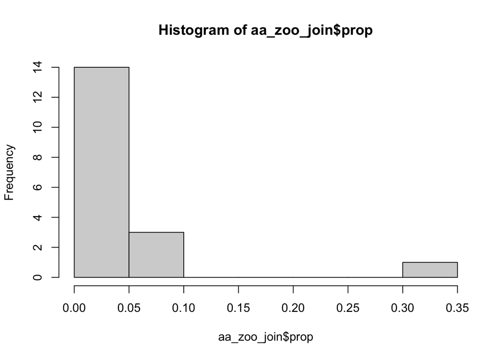

```r
hist(aa_zoo_join$prop)
```

try transforming the proportions let’s go with a arcsine tranformation (the alternative logit transformation does something weird with 0’s)

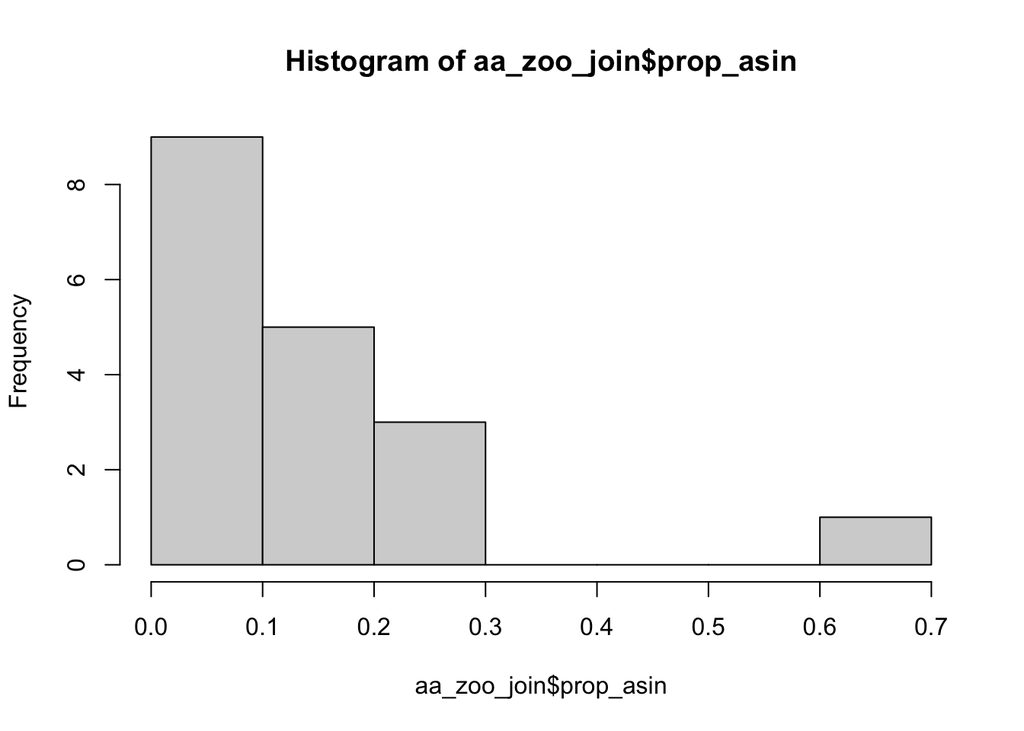

```r
asinTransform <- function(p) { asin(sqrt(p)) }

aa_zoo_join$prop_asin <- asinTransform(aa_zoo_join$prop)

hist(aa_zoo_join$prop_asin)
```

now try some glm’s with original proportions

```r
Z0 <- glm(prop ~ 1, family = binomial, data = aa_zoo_join, weights = sampled)
Z1 <- glm(prop ~ Field_Type, family = binomial, data = aa_zoo_join, weights = sampled)
Z2 <- glm(prop ~ PC1_500m, family = binomial, data = aa_zoo_join, weights = sampled)
Z3 <- glm(prop ~ PC1_500m + Field_Type, family = binomial, data = aa_zoo_join, weights = sampled)
Z4 <- glm(prop ~ PC1_500m * Field_Type, family = binomial, data = aa_zoo_join, weights = sampled)

AICc(Z0, Z1, Z2, Z3, Z4)
```

```
##    df     AICc
## Z0  1 50.04113
## Z1  2 51.77527
## Z2  2 50.10279
## Z3  3 50.00976
## Z4  4 50.73776
```

all models are VERY similar… models with explanatory variables are no better than the null

now try some glm’s with the transformed data

```r
Z0 <- glm(prop_asin ~ 1, family = binomial, data = aa_zoo_join, weights = sampled)
Z1 <- glm(prop_asin ~ Field_Type, family = binomial, data = aa_zoo_join, weights = sampled)
Z2 <- glm(prop_asin ~ PC1_500m, family = binomial, data = aa_zoo_join, weights = sampled)
Z3 <- glm(prop_asin ~ PC1_500m + Field_Type, family = binomial, data = aa_zoo_join, weights = sampled)
Z4 <- glm(prop_asin ~ PC1_500m * Field_Type, family = binomial, data = aa_zoo_join, weights = sampled)
AICc(Z0, Z1, Z2, Z3, Z4)
```

```
##    df     AICc
## Z0  1 116.9544
## Z1  2 112.3869
## Z2  2 118.8524
## Z3  3 110.5189
## Z4  4 107.3017
```

alrighty, the model with PC1 at 500m, field type, AND there interaction is the top model

look at the model

```r
summary(Z4)
```

```
##
## Call:
## glm(formula = prop_asin ~ PC1_500m * Field_Type, family = binomial,
##     data = aa_zoo_join, weights = sampled)
##
## Deviance Residuals:
##     Min       1Q   Median       3Q      Max
## -4.5866  -1.4967  -0.0922   0.9071   2.1601
##
## Coefficients:
##                            Estimate Std. Error z value Pr(>|z|)
## (Intercept)                 -2.8360     0.4949  -5.731    1e-08 ***
## PC1_500m                     0.5121     0.3322   1.541 0.123232
## Field_TypeNatural            1.8951     0.5455   3.474 0.000513 ***
## PC1_500m:Field_TypeNatural  -0.8606     0.3528  -2.439 0.014717 *
## ---
## Signif. codes:  0 '***' 0.001 '**' 0.01 '*' 0.05 '.' 0.1 ' ' 1
##
## (Dispersion parameter for binomial family taken to be 1)
##
##     Null deviance: 78.028  on 15  degrees of freedom
## Residual deviance: 60.377  on 12  degrees of freedom
## AIC: 104.22
##
## Number of Fisher Scoring iterations: 5
```

pseudo R2

```r
100*(78.028/60.377)/78.028
```

```
## [1] 1.65626
```

this is very low… maybe there is a different way to calculate a psuedo R2 for proportion data

model validation

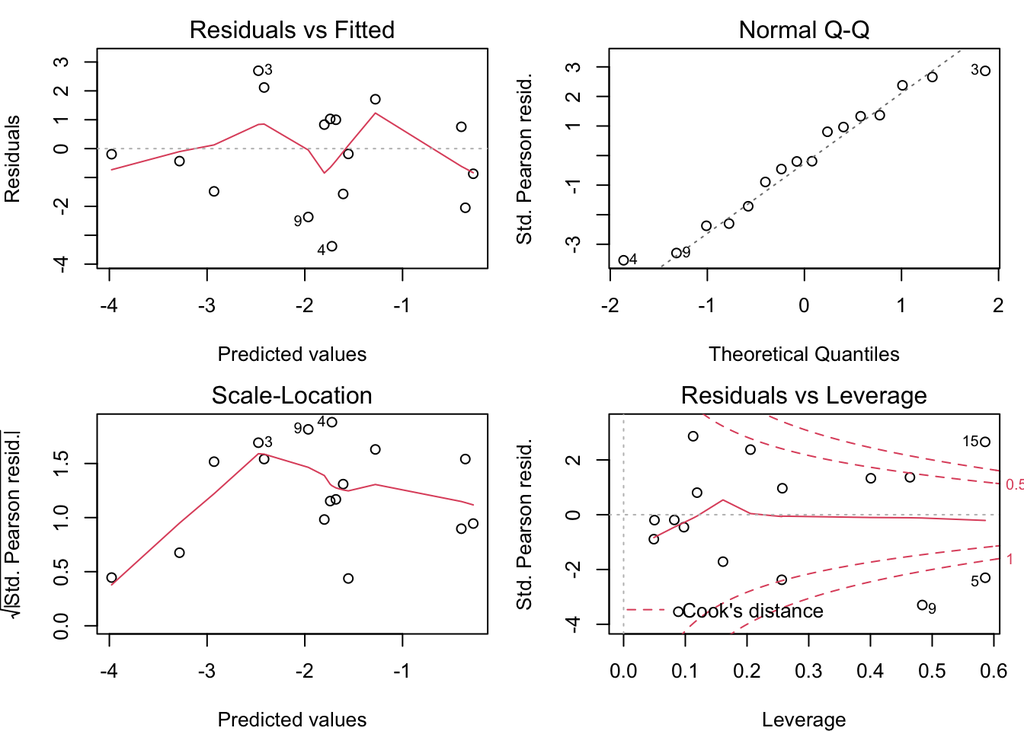

```r
par(mfrow=c(2,2), mar=c(4,4,2,1))
plot(Z4, which = 1)
plot(Z4, which = 2)
plot(Z4, which = 3)
plot(Z4, which = 5)
```

sites 5, 9, and 15 are outside the envelope

### proportion of any zoonotic pathogen (screened dataset)

repeat models for propotion but screen out sites 5,9, and 15

```r
aa_zoo_join_screen <- aa_zoo_join[-c(5,9,15),]

Z0.screen <- glm(prop_asin ~ 1, family = binomial, data = aa_zoo_join_screen, weights = sampled)
Z1.screen <- glm(prop_asin ~ Field_Type, family = binomial, data = aa_zoo_join_screen, weights = sampled)
Z2.screen <- glm(prop_asin ~ PC1_500m, family = binomial, data = aa_zoo_join_screen, weights = sampled)
Z3.screen  <- glm(prop_asin ~ PC1_500m + Field_Type, family = binomial, data = aa_zoo_join_screen, weights = sampled)
Z4.screen  <- glm(prop_asin ~ PC1_500m * Field_Type, family = binomial, data = aa_zoo_join_screen, weights = sampled)
AICc(Z0.screen , Z1.screen , Z2.screen , Z3.screen , Z4.screen )
```

```
##           df     AICc
## Z0.screen  1 66.85258
## Z1.screen  2 68.12762
## Z2.screen  2 69.53748
## Z3.screen  3 71.03115
## Z4.screen  4 73.81693
```

lowest AIC is now the null model…

```r
summary(Z1.screen)
```

```
##
## Call:
## glm(formula = prop_asin ~ Field_Type, family = binomial, data = aa_zoo_join_screen,
##     weights = sampled)
##
## Deviance Residuals:
##     Min       1Q   Median       3Q      Max
## -4.4569  -0.9260   0.0000   0.5729   1.8772
##
## Coefficients:
##                   Estimate Std. Error z value Pr(>|z|)
## (Intercept)        -1.3690     0.3085  -4.438 9.09e-06 ***
## Field_TypeNatural  -0.4156     0.3264  -1.273    0.203
## ---
## Signif. codes:  0 '***' 0.001 '**' 0.01 '*' 0.05 '.' 0.1 ' ' 1
##
## (Dispersion parameter for binomial family taken to be 1)
##
##     Null deviance: 34.089  on 12  degrees of freedom
## Residual deviance: 32.574  on 11  degrees of freedom
## AIC: 67.128
##
## Number of Fisher Scoring iterations: 4
```

```r
summary(Z2.screen)
```

```
##
## Call:
## glm(formula = prop_asin ~ PC1_500m, family = binomial, data = aa_zoo_join_screen,
##     weights = sampled)
##
## Deviance Residuals:
##     Min       1Q   Median       3Q      Max
## -4.5372  -0.9372   0.0000   0.8311   1.8352
##
## Coefficients:
##              Estimate Std. Error z value Pr(>|z|)
## (Intercept) -1.735983   0.326569  -5.316 1.06e-07 ***
## PC1_500m    -0.004431   0.152513  -0.029    0.977
## ---
## Signif. codes:  0 '***' 0.001 '**' 0.01 '*' 0.05 '.' 0.1 ' ' 1
##
## (Dispersion parameter for binomial family taken to be 1)
##
##     Null deviance: 34.089  on 12  degrees of freedom
## Residual deviance: 34.088  on 11  degrees of freedom
## AIC: 68.537
##
## Number of Fisher Scoring iterations: 4
```

okay so the proportion of A. americanum infected with a zoonotic pathogen is NOT influenced by field type or the PC1 axis

### proportion of any ehrlichia pathogen (full dataset)

join site covariates to aa_ehr summary

```r
aa_ehr_join <- aa_ehr %>%
  left_join(covar, by = "Site_ID")
aa_ehr_join
```

```
## # A tibble: 18 × 28
## # Groups:   Site_ID [18]
##    Site_ID   neg   pos sampled   prop pos_site Site  Easting Northing Field_Type
##    <chr>   <int> <dbl>   <dbl>  <dbl>    <dbl> <chr>   <dbl>    <dbl> <chr>
##  1 29RD        6     0       6 0             0 "29t… 370183. 3284095. Natural
##  2 DF         26     1      27 0.0370        1 "Dud… 350804. 3281711. Manicured
##  3 FC         14     0      14 0             0 "Fre… 375390. 3280603. Manicured
##  4 HC         64     0      64 0             0 "Hat… 381436. 3285055. Natural
##  5 HT         41     0      41 0             0 "Hog… 370034. 3285928. Manicured
##  6 HW          1     0       1 0             0 "Har… 368536. 3280276. Natural
##  7 JM          2     1       3 0.333         1 "Joh… 365650. 3281144. Natural
##  8 LL         17     0      17 0             0 "Lon… 384712. 3271218. Manicured
##  9 MSM        40     0      40 0             0 "Mor… 376482. 3281179. Manicured
## 10 MSN       269     6     275 0.0218        1 "Mor… 376592. 3281485. Natural
## 11 PC          5     0       5 0             0 "Pos… 365990. 3286586. Manicured
## 12 PP        144     3     147 0.0204        1 "Pay… 375374. 3267131. Natural
## 13 RP          2     0       2 0             0 "Res… 373075. 3281598. Manicured
## 14 SF        142     2     144 0.0139        1 "San… 358760. 3288083  Natural
## 15 SR        191     9     200 0.045         1 "Spl… 363585. 3279533. Natural
## 16 SW         72     1      73 0.0137        1 "Swe… 372417. 3278202. Natural
## 17 UG          0     0       0 0             0 "Uni… 368562. 3280166. Manicured
## 18 GA          0     0       0 0             0 "Gre… 366139. 3280294. Manicured
## # … with 18 more variables: Forest250m <dbl>, Forest500m <dbl>,
## #   Forest1km <dbl>, Forest2km <dbl>, Forest3km <dbl>, Forest4km <dbl>,
## #   PC1_250m <dbl>, PC2_250m <dbl>, PC1_500m <dbl>, PC2_500m <dbl>,
## #   PC1_1km <dbl>, PC2_1km <dbl>, PC1_2km <dbl>, PC2_2km <dbl>, PC1_3km <dbl>,
## #   PC2_3km <dbl>, PC1_4km <dbl>, PC2_4km <dbl>
```

plot the distribution of proportions

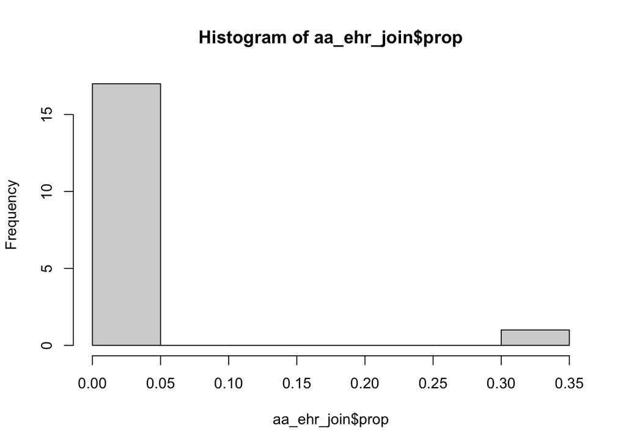

```r
hist(aa_ehr_join$prop)
```

try transforming the proportions let’s go with a arcsine tranformation (the alternative logit transformation does something weird with 0’s)

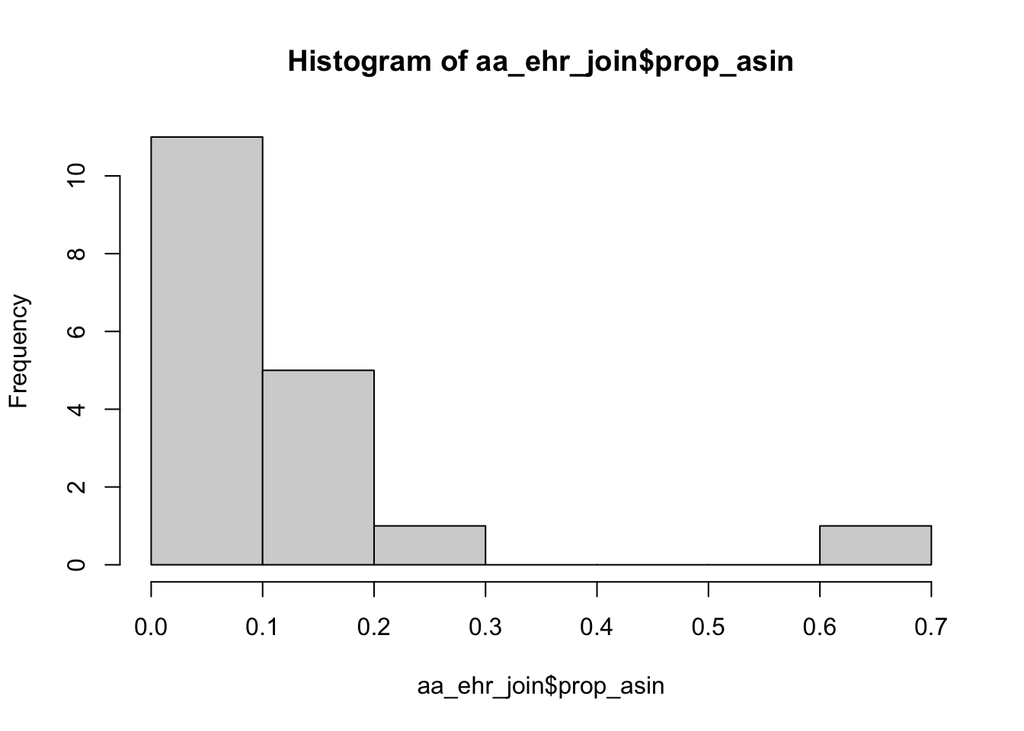

```r
asinTransform <- function(p) { asin(sqrt(p)) }

aa_ehr_join$prop_asin <- asinTransform(aa_ehr_join$prop)

hist(aa_ehr_join$prop_asin)
```

now try some glm’s with original proportions

```r
Z0 <- glm(prop ~ 1, family = binomial, data = aa_ehr_join, weights = sampled)
Z1 <- glm(prop ~ Field_Type, family = binomial, data = aa_ehr_join, weights = sampled)
Z2 <- glm(prop ~ PC1_500m, family = binomial, data = aa_ehr_join, weights = sampled)
Z3 <- glm(prop ~ PC1_500m + Field_Type, family = binomial, data = aa_ehr_join, weights = sampled)
Z4 <- glm(prop ~ PC1_500m * Field_Type, family = binomial, data = aa_ehr_join, weights = sampled)

AICc(Z0, Z1, Z2, Z3, Z4)
```

```
##    df     AICc
## Z0  1 38.20714
## Z1  2 38.45579
## Z2  2 39.09294
## Z3  3 37.11346
## Z4  4 40.21982
```

model with PC1 and field type best

```r
summary(Z3)
```

```
##
## Call:
## glm(formula = prop ~ PC1_500m + Field_Type, family = binomial,
##     data = aa_ehr_join, weights = sampled)
##
## Deviance Residuals:
##     Min       1Q   Median       3Q      Max
## -1.5604  -0.6064  -0.3581   0.2435   1.4032
##
## Coefficients:
##                   Estimate Std. Error z value Pr(>|z|)
## (Intercept)        -4.6801     1.0070  -4.647 3.36e-06 ***
## PC1_500m           -0.5090     0.2215  -2.298   0.0216 *
## Field_TypeNatural   1.8690     1.0653   1.754   0.0794 .
## ---
## Signif. codes:  0 '***' 0.001 '**' 0.01 '*' 0.05 '.' 0.1 ' ' 1
##
## (Dispersion parameter for binomial family taken to be 1)
##
##     Null deviance: 17.173  on 15  degrees of freedom
## Residual deviance: 10.615  on 13  degrees of freedom
## AIC: 35.399
##
## Number of Fisher Scoring iterations: 6
```

pseudo R2

```r
100*(17.173/10.615)/17.173
```

```
## [1] 9.420631
```

model validation

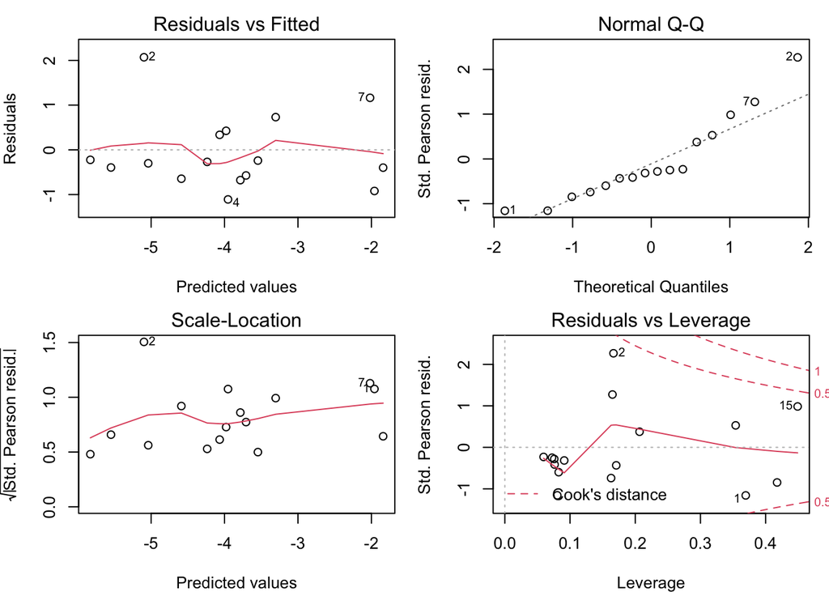

```r
par(mfrow=c(2,2), mar=c(4,4,2,1))
plot(Z3, which = 1)
plot(Z3, which = 2)
plot(Z3, which = 3)
plot(Z3, which = 5)
```

probably do not need to filter out any sites…

now try some glm’s with the transformed data

```r
Z0 <- glm(prop_asin ~ 1, family = binomial, data = aa_ehr_join, weights = sampled)
Z1 <- glm(prop_asin ~ Field_Type, family = binomial, data = aa_ehr_join, weights = sampled)
Z2 <- glm(prop_asin ~ PC1_500m, family = binomial, data = aa_ehr_join, weights = sampled)
Z3 <- glm(prop_asin ~ PC1_500m + Field_Type, family = binomial, data = aa_ehr_join, weights = sampled)
Z4 <- glm(prop_asin ~ PC1_500m * Field_Type, family = binomial, data = aa_ehr_join, weights = sampled)
AICc(Z0, Z1, Z2, Z3, Z4)
```

```
##    df      AICc
## Z0  1 101.57893
## Z1  2  86.11930
## Z2  2 104.01827
## Z3  3  83.79416
## Z4  4  86.78340
```

model with PC1 and field type best

```r
summary(Z3)
```

```
##
## Call:
## glm(formula = prop_asin ~ PC1_500m + Field_Type, family = binomial,
##     data = aa_ehr_join, weights = sampled)
##
## Deviance Residuals:
##     Min       1Q   Median       3Q      Max
## -4.2442  -0.9841  -0.7458   0.5120   3.1817
##
## Coefficients:
##                   Estimate Std. Error z value Pr(>|z|)
## (Intercept)        -3.0966     0.4516  -6.857 7.01e-12 ***
## PC1_500m           -0.2765     0.1219  -2.268 0.023339 *
## Field_TypeNatural   1.8270     0.4792   3.813 0.000137 ***
## ---
## Signif. codes:  0 '***' 0.001 '**' 0.01 '*' 0.05 '.' 0.1 ' ' 1
##
## (Dispersion parameter for binomial family taken to be 1)
##
##     Null deviance: 69.617  on 15  degrees of freedom
## Residual deviance: 47.661  on 13  degrees of freedom
## AIC: 82.08
##
## Number of Fisher Scoring iterations: 5
```

pseudo R2

```r
100*(69.617/47.661)/69.617
```

```
## [1] 2.098152
```

this is very low… maybe there is a different way to calculate a psuedo R2 for proportion data  
this is even lower than the untransformed data… put the p-values are more significant…

model validation

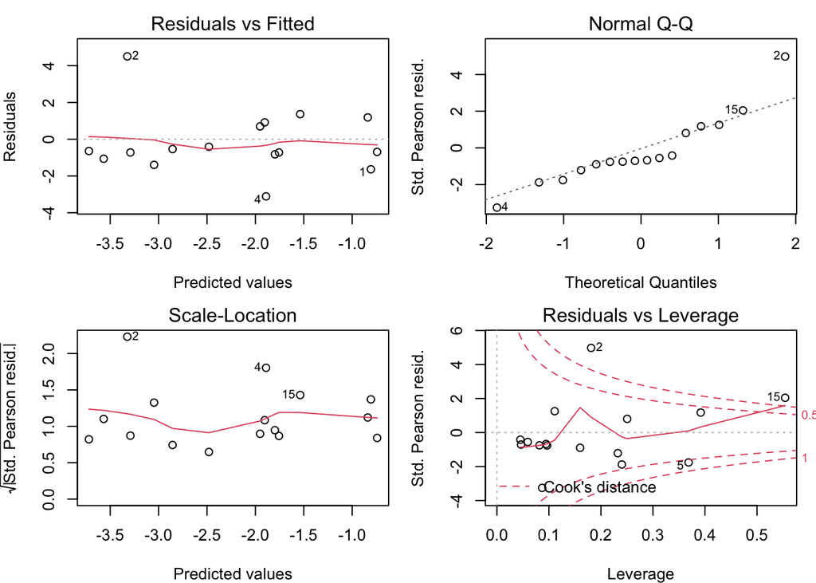

```r
par(mfrow=c(2,2), mar=c(4,4,2,1))
plot(Z3, which = 1)
plot(Z3, which = 2)
plot(Z3, which = 3)
plot(Z3, which = 5)
```

sites 2 and 15 may need be be removed…

### proportion of any ehrlichia pathogen (screened dataset)

only the dataset with the transformed response might need sites removed

```r
aa_ehr_join_screen <- aa_ehr_join[-c(2,15),]

Z0 <- glm(prop_asin ~ 1, family = binomial, data = aa_ehr_join_screen, weights = sampled)
Z1 <- glm(prop_asin ~ Field_Type, family = binomial, data = aa_ehr_join_screen, weights = sampled)
Z2 <- glm(prop_asin ~ PC1_500m, family = binomial, data = aa_ehr_join_screen, weights = sampled)
Z3 <- glm(prop_asin ~ PC1_500m + Field_Type, family = binomial, data = aa_ehr_join_screen, weights = sampled)
Z4 <- glm(prop_asin ~ PC1_500m * Field_Type, family = binomial, data = aa_ehr_join_screen, weights = sampled)
AICc(Z0, Z1, Z2, Z3, Z4)
```

```
##    df     AICc
## Z0  1 77.65223
## Z1  2 50.74238
## Z2  2 73.92917
## Z3  3 53.76179
## Z4  4 57.39815
```

model with just field type best

```r
summary(Z1)
```

```
##
## Call:
## glm(formula = prop_asin ~ Field_Type, family = binomial, data = aa_ehr_join_screen,
##     weights = sampled)
##
## Deviance Residuals:
##     Min       1Q   Median       3Q      Max
## -4.1376  -0.2186  -0.0001   0.0000   1.9962
##
## Coefficients:
##                   Estimate Std. Error z value Pr(>|z|)
## (Intercept)         -21.53    2627.78  -0.008    0.993
## Field_TypeNatural    19.58    2627.78   0.007    0.994
##
## (Dispersion parameter for binomial family taken to be 1)
##
##     Null deviance: 54.072  on 13  degrees of freedom
## Residual deviance: 24.783  on 12  degrees of freedom
## AIC: 49.819
##
## Number of Fisher Scoring iterations: 18
```

field site is not significant in the best model

### proportion of Theileria cervi (full dataset)

join site covariates to aa_tc summary

```r
aa_tc_join <- aa_tc %>%
  left_join(covar, by = "Site_ID")
aa_tc_join
```

```
## # A tibble: 18 × 28
## # Groups:   Site_ID [18]
##    Site_ID   neg   pos sampled   prop pos_site Site  Easting Northing Field_Type
##    <chr>   <int> <dbl>   <dbl>  <dbl>    <dbl> <chr>   <dbl>    <dbl> <chr>
##  1 29RD        6     0       6 0             0 "29t… 370183. 3284095. Natural
##  2 DF         24     3      27 0.111         1 "Dud… 350804. 3281711. Manicured
##  3 FC         14     0      14 0             0 "Fre… 375390. 3280603. Manicured
##  4 HC         60     4      64 0.0625        1 "Hat… 381436. 3285055. Natural
##  5 HT         40     1      41 0.0244        1 "Hog… 370034. 3285928. Manicured
##  6 HW          1     0       1 0             0 "Har… 368536. 3280276. Natural
##  7 JM          3     0       3 0             0 "Joh… 365650. 3281144. Natural
##  8 LL         16     1      17 0.0588        1 "Lon… 384712. 3271218. Manicured
##  9 MSM        39     1      40 0.025         1 "Mor… 376482. 3281179. Manicured
## 10 MSN       263    12     275 0.0436        1 "Mor… 376592. 3281485. Natural
## 11 PC          5     0       5 0             0 "Pos… 365990. 3286586. Manicured
## 12 PP        139     8     147 0.0544        1 "Pay… 375374. 3267131. Natural
## 13 RP          2     0       2 0             0 "Res… 373075. 3281598. Manicured
## 14 SF        139     5     144 0.0347        1 "San… 358760. 3288083  Natural
## 15 SR        187    13     200 0.065         1 "Spl… 363585. 3279533. Natural
## 16 SW         73     0      73 0             0 "Swe… 372417. 3278202. Natural
## 17 UG          0     0       0 0             0 "Uni… 368562. 3280166. Manicured
## 18 GA          0     0       0 0             0 "Gre… 366139. 3280294. Manicured
## # … with 18 more variables: Forest250m <dbl>, Forest500m <dbl>,
## #   Forest1km <dbl>, Forest2km <dbl>, Forest3km <dbl>, Forest4km <dbl>,
## #   PC1_250m <dbl>, PC2_250m <dbl>, PC1_500m <dbl>, PC2_500m <dbl>,
## #   PC1_1km <dbl>, PC2_1km <dbl>, PC1_2km <dbl>, PC2_2km <dbl>, PC1_3km <dbl>,
## #   PC2_3km <dbl>, PC1_4km <dbl>, PC2_4km <dbl>
```

plot the distribution of proportions

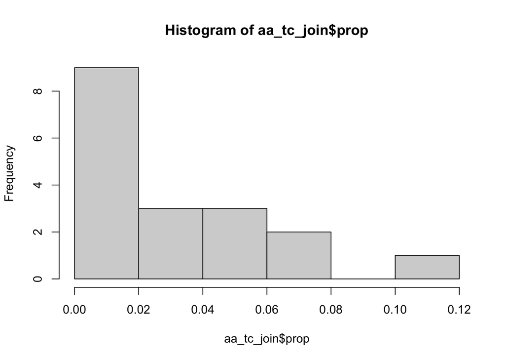

```r
hist(aa_tc_join$prop)
```

try transforming the proportions let’s go with a arcsine tranformation (the alternative logit transformation does something weird with 0’s)

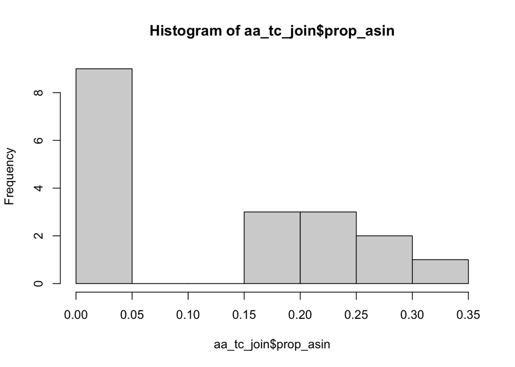

```r
asinTransform <- function(p) { asin(sqrt(p)) }

aa_tc_join$prop_asin <- asinTransform(aa_tc_join$prop)

hist(aa_tc_join$prop_asin)
```

transforming actually looks worse so i will only try original proportions

now try some glm’s with original proportions

```r
Z0 <- glm(prop ~ 1, family = binomial, data = aa_tc_join, weights = sampled)
Z1 <- glm(prop ~ Field_Type, family = binomial, data = aa_tc_join, weights = sampled)
Z2 <- glm(prop ~ PC1_500m, family = binomial, data = aa_tc_join, weights = sampled)
Z3 <- glm(prop ~ PC1_500m + Field_Type, family = binomial, data = aa_tc_join, weights = sampled)
Z4 <- glm(prop ~ PC1_500m * Field_Type, family = binomial, data = aa_tc_join, weights = sampled)

AICc(Z0, Z1, Z2, Z3, Z4)
```

```
##    df     AICc
## Z0  1 45.46647
## Z1  2 47.94462
## Z2  2 47.96571
## Z3  3 50.84501
## Z4  4 53.92382
```

null model is best

```r
summary(Z0)
```

```
##
## Call:
## glm(formula = prop ~ 1, family = binomial, data = aa_tc_join,
##     weights = sampled)
##
## Deviance Residuals:
##     Min       1Q   Median       3Q      Max
## -2.6023  -0.6791  -0.3677   0.1922   1.3974
##
## Coefficients:
##             Estimate Std. Error z value Pr(>|z|)
## (Intercept)  -3.0475     0.1477  -20.63   <2e-16 ***
## ---
## Signif. codes:  0 '***' 0.001 '**' 0.01 '*' 0.05 '.' 0.1 ' ' 1
##
## (Dispersion parameter for binomial family taken to be 1)
##
##     Null deviance: 15.282  on 15  degrees of freedom
## Residual deviance: 15.282  on 15  degrees of freedom
## AIC: 45.216
##
## Number of Fisher Scoring iterations: 4
```

## presence/absence at the site level

### presense/absence of any zoonotic pathogen at the site level

try out a set of models that is for pres/abs of pathogen at the site level

```r
P0 <- glm(pos_site ~ 1, family = binomial, data = aa_zoo_join)
P1 <- glm(pos_site ~ Field_Type, family = binomial, data = aa_zoo_join)
P2 <- glm(pos_site ~ PC1_500m, family = binomial, data = aa_zoo_join)
P3 <- glm(pos_site ~ PC1_500m + Field_Type, family = binomial, data = aa_zoo_join)
P4 <- glm(pos_site ~ PC1_500m * Field_Type, family = binomial, data = aa_zoo_join)

AICc(P0, P1, P2, P3, P4)
```

```
##    df     AICc
## P0  1 27.20330
## P1  2 27.71451
## P2  2 23.99353
## P3  3 25.57479
## P4  4 28.23066
```

top model for pres/abs at a site is P2 (PC1 at 500m)

look at the model

```r
summary(P2)
```

```
##
## Call:
## glm(formula = pos_site ~ PC1_500m, family = binomial, data = aa_zoo_join)
##
## Deviance Residuals:
##      Min        1Q    Median        3Q       Max
## -1.81082  -0.71658   0.07033   0.76914   1.90236
##
## Coefficients:
##             Estimate Std. Error z value Pr(>|z|)
## (Intercept)  -0.3793     0.6049  -0.627   0.5306
## PC1_500m      0.8040     0.3891   2.066   0.0388 *
## ---
## Signif. codes:  0 '***' 0.001 '**' 0.01 '*' 0.05 '.' 0.1 ' ' 1
##
## (Dispersion parameter for binomial family taken to be 1)
##
##     Null deviance: 24.953  on 17  degrees of freedom
## Residual deviance: 19.194  on 16  degrees of freedom
## AIC: 23.194
##
## Number of Fisher Scoring iterations: 4
```

model fit

```r
100*(24.953-19.194)/24.953
```

```
## [1] 23.07939
```

model validation

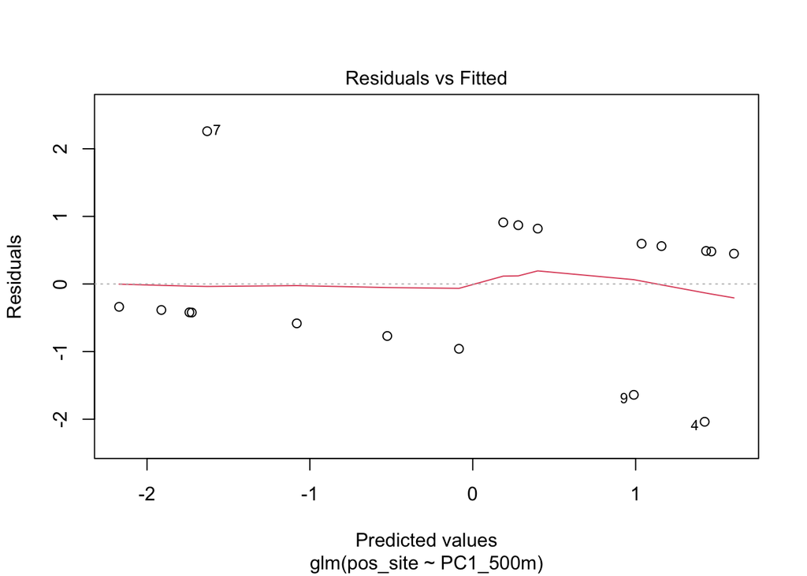

```r
plot(P2, which = 1)
```

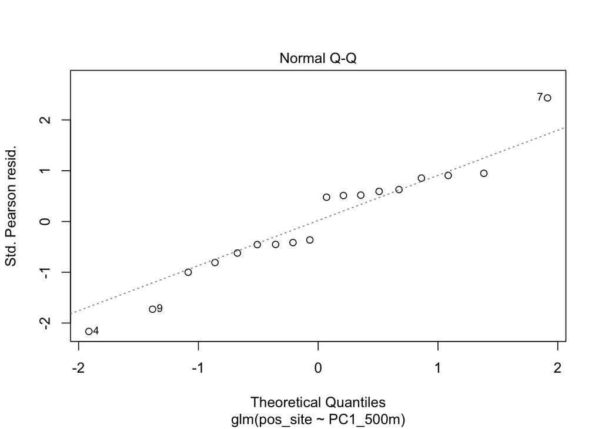

```r
plot(P2, which = 2)
```

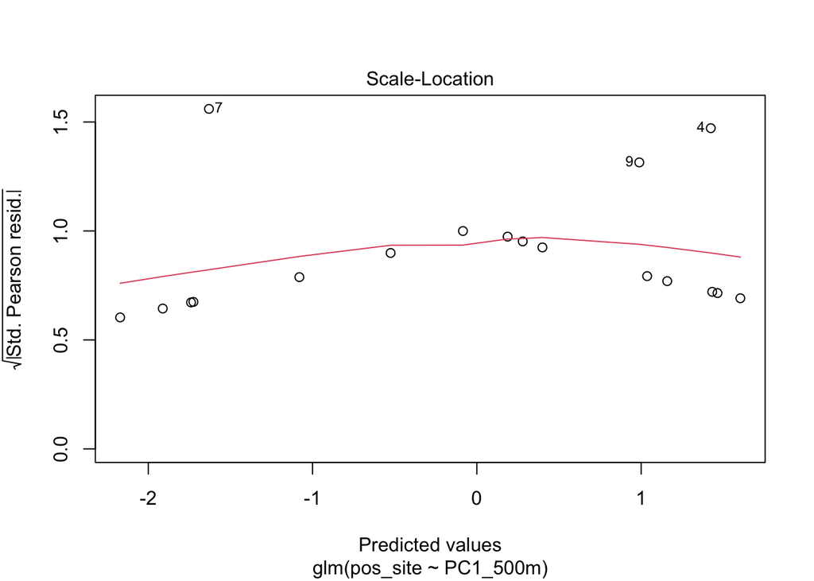

```r
plot(P2, which = 3)
```

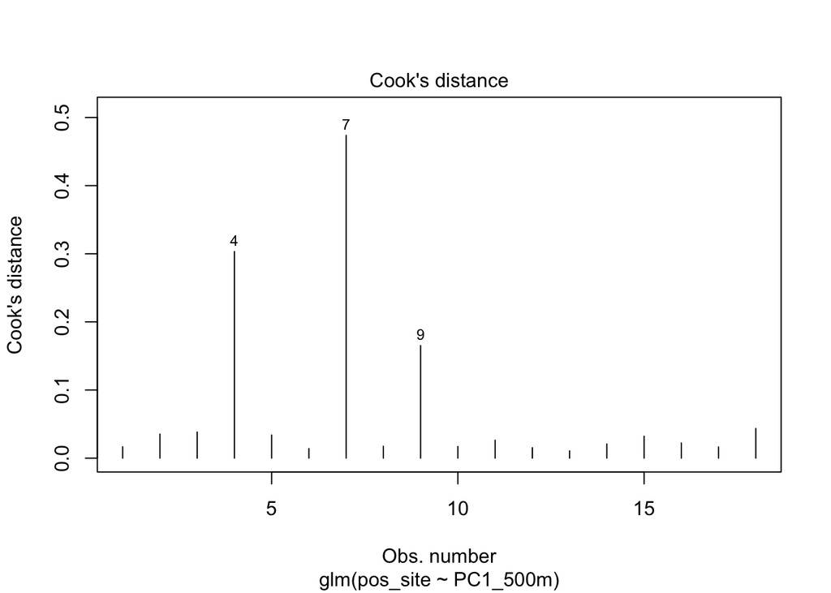

```r
plot(P2, which = 4)
```

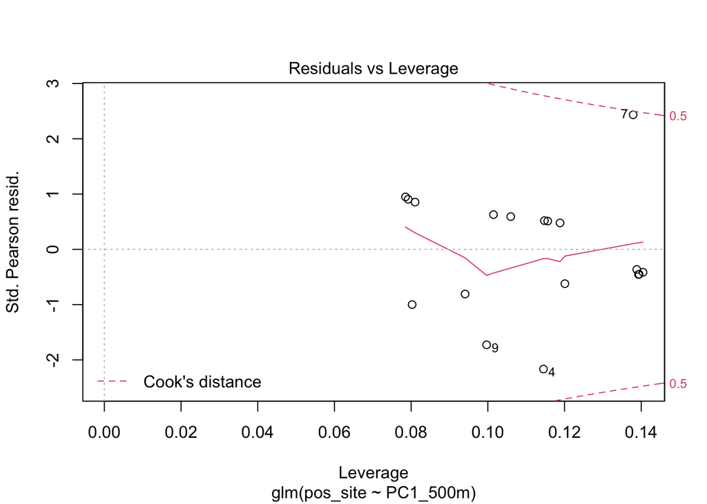

```r
plot(P2, which = 5)
```

plot the prediction

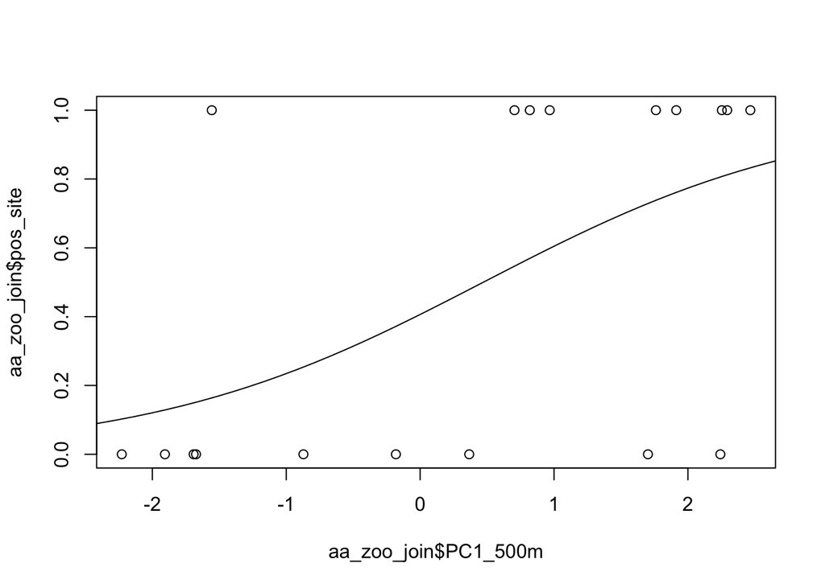

```r
mydata <- data.frame(PC1_500m = seq(-3,3, length = 50))
mydata$pred <- predict(P2, newdata = mydata, type = "response")
plot(x = aa_zoo_join$PC1_500m, y = aa_zoo_join$pos_site)
lines(mydata$PC1_500m, mydata$pred)
```

### presense/absence of any Ehrlichia pathogen at the site level

try out a set of models that is for pres/abs of pathogen at the site level

```r
#aa_ehr_join$pos_site <- as.factor(aa_ehr_join$pos_site)
#levels(aa_ehr_join$pos_site) <- c("0", "1")

P0 <- glm(pos_site ~ 1, family = binomial, data = aa_ehr_join)
P1 <- glm(pos_site ~ Field_Type, family = binomial, data = aa_ehr_join)
P2 <- glm(pos_site ~ PC1_500m, family = binomial, data = aa_ehr_join)
P3 <- glm(pos_site ~ PC1_500m + Field_Type, family = binomial, data = aa_ehr_join)
P4 <- glm(pos_site ~ PC1_500m * Field_Type, family = binomial, data = aa_ehr_join)

AICc(P0, P1, P2, P3, P4)
```

```
##    df     AICc
## P0  1 26.30695
## P1  2 22.53623
## P2  2 25.67205
## P3  3 23.18391
## P4  4 26.53070
```

top model for pres/abs at a site is P1 (field type)

look at the model

```r
summary(P1)
```

```
##
## Call:
## glm(formula = pos_site ~ Field_Type, family = binomial, data = aa_ehr_join)
##
## Deviance Residuals:
##     Min       1Q   Median       3Q      Max
## -1.4823  -0.4854  -0.4854   0.9005   2.0963
##
## Coefficients:
##                   Estimate Std. Error z value Pr(>|z|)
## (Intercept)         -2.079      1.061  -1.961   0.0499 *
## Field_TypeNatural    2.773      1.275   2.175   0.0296 *
## ---
## Signif. codes:  0 '***' 0.001 '**' 0.01 '*' 0.05 '.' 0.1 ' ' 1
##
## (Dispersion parameter for binomial family taken to be 1)
##
##     Null deviance: 24.057  on 17  degrees of freedom
## Residual deviance: 17.736  on 16  degrees of freedom
## AIC: 21.736
##
## Number of Fisher Scoring iterations: 4
```

```r
summary(P3)
```

```
##
## Call:
## glm(formula = pos_site ~ PC1_500m + Field_Type, family = binomial,
##     data = aa_ehr_join)
##
## Deviance Residuals:
##     Min       1Q   Median       3Q      Max
## -1.9202  -0.6242  -0.3033   0.6235   2.0194
##
## Coefficients:
##                   Estimate Std. Error z value Pr(>|z|)
## (Intercept)        -2.3552     1.1382  -2.069   0.0385 *
## PC1_500m            0.5563     0.3935   1.414   0.1575
## Field_TypeNatural   2.7790     1.3636   2.038   0.0416 *
## ---
## Signif. codes:  0 '***' 0.001 '**' 0.01 '*' 0.05 '.' 0.1 ' ' 1
##
## (Dispersion parameter for binomial family taken to be 1)
##
##     Null deviance: 24.057  on 17  degrees of freedom
## Residual deviance: 15.470  on 15  degrees of freedom
## AIC: 21.47
##
## Number of Fisher Scoring iterations: 5
```

model fit

```r
100*(24.057-17.736)/24.057
```

```
## [1] 26.2751
```

```r
100*(24.057-15.470 )/24.057
```

```
## [1] 35.69439
```

AIC and model fit is better for the model that include both field type and PC1

model validation

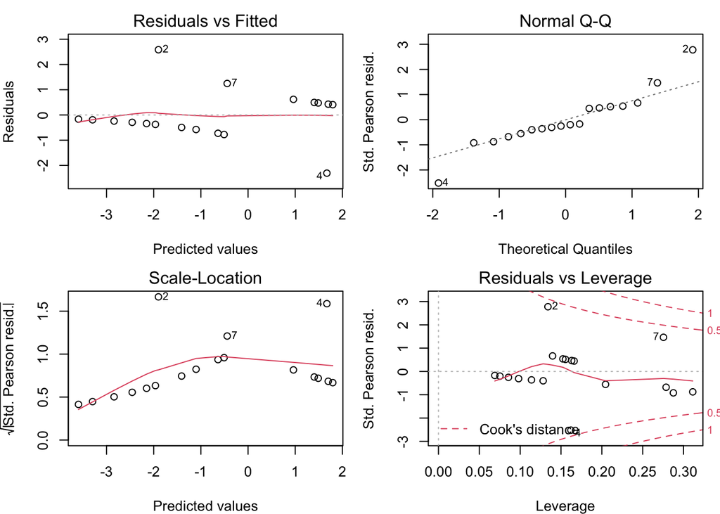

```r
par(mfrow=c(2,2), mar=c(4,4,2,1))
plot(P3, which = 1)
plot(P3, which = 2)
plot(P3, which = 3)
plot(P3, which = 5)
```

looks okay!

plot the prediction

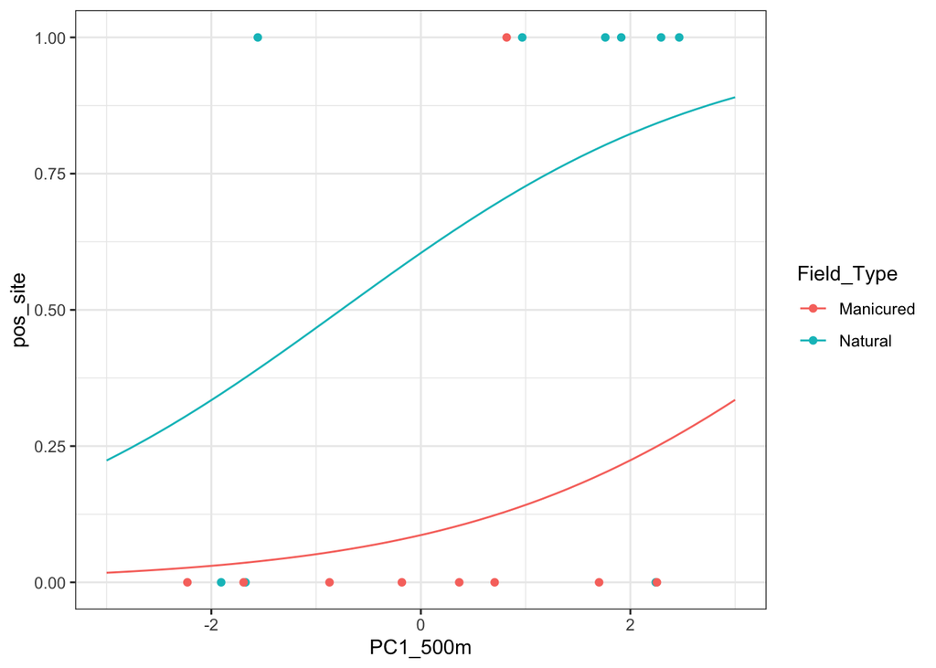

```r
mydata <- expand.grid(PC1_500m = seq(-3,3, length = 50), Field_Type = c("Natural","Manicured"))
mydata$pred <- predict(P3, newdata = mydata, type = "response")

ggplot(aa_ehr_join, aes(x = PC1_500m, y = pos_site, group = Field_Type)) +
  geom_point(aes(color = Field_Type)) +
  geom_line(data = mydata, aes(x = PC1_500m, y = pred, color = Field_Type)) +
  theme_bw()
```

i f’d up changing the pres/ab to a factor and now it is funky…

### presense/absence of Theileria cervi at the site level

try out a set of models that is for pres/abs of pathogen at the site level

```r
P0 <- glm(pos_site ~ 1, family = binomial, data = aa_tc_join)
P1 <- glm(pos_site ~ Field_Type, family = binomial, data = aa_tc_join)
P2 <- glm(pos_site ~ PC1_500m, family = binomial, data = aa_tc_join)
P3 <- glm(pos_site ~ PC1_500m + Field_Type, family = binomial, data = aa_tc_join)
P4 <- glm(pos_site ~ PC1_500m * Field_Type, family = binomial, data = aa_tc_join)

AICc(P0, P1, P2, P3, P4)
```

```
##    df     AICc
## P0  1 27.20330
## P1  2 29.53062
## P2  2 17.79003
## P3  3 20.52373
## P4  4 23.88396
```

top model for pres/abs at a site is P2 (PC1 at 500m)

look at the model

```r
summary(P2)
```

```
##
## Call:
## glm(formula = pos_site ~ PC1_500m, family = binomial, data = aa_tc_join)
##
## Deviance Residuals:
##      Min        1Q    Median        3Q       Max
## -1.96045  -0.28268   0.08274   0.48020   1.67365
##
## Coefficients:
##             Estimate Std. Error z value Pr(>|z|)
## (Intercept)  -0.8488     0.8671  -0.979    0.328
## PC1_500m      1.4835     0.6476   2.291    0.022 *
## ---
## Signif. codes:  0 '***' 0.001 '**' 0.01 '*' 0.05 '.' 0.1 ' ' 1
##
## (Dispersion parameter for binomial family taken to be 1)
##
##     Null deviance: 24.953  on 17  degrees of freedom
## Residual deviance: 12.990  on 16  degrees of freedom
## AIC: 16.99
##
## Number of Fisher Scoring iterations: 5
```

model fit

```r
100*(24.953-12.990)/24.953
```

```
## [1] 47.94213
```

model validation

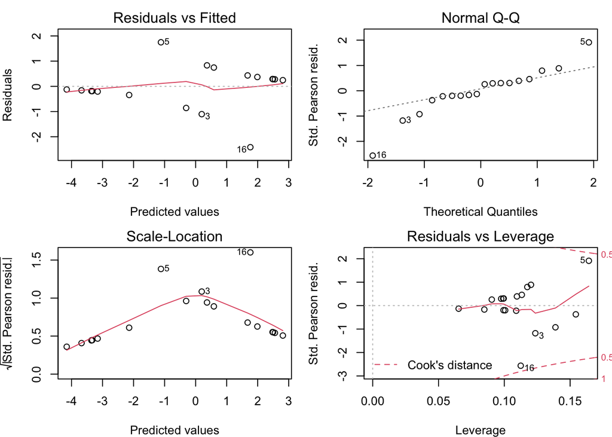

```r
par(mfrow=c(2,2), mar=c(4,4,2,1))
plot(P2, which = 1)
plot(P2, which = 2)
plot(P2, which = 3)
plot(P2, which = 5)
```

plot the prediction

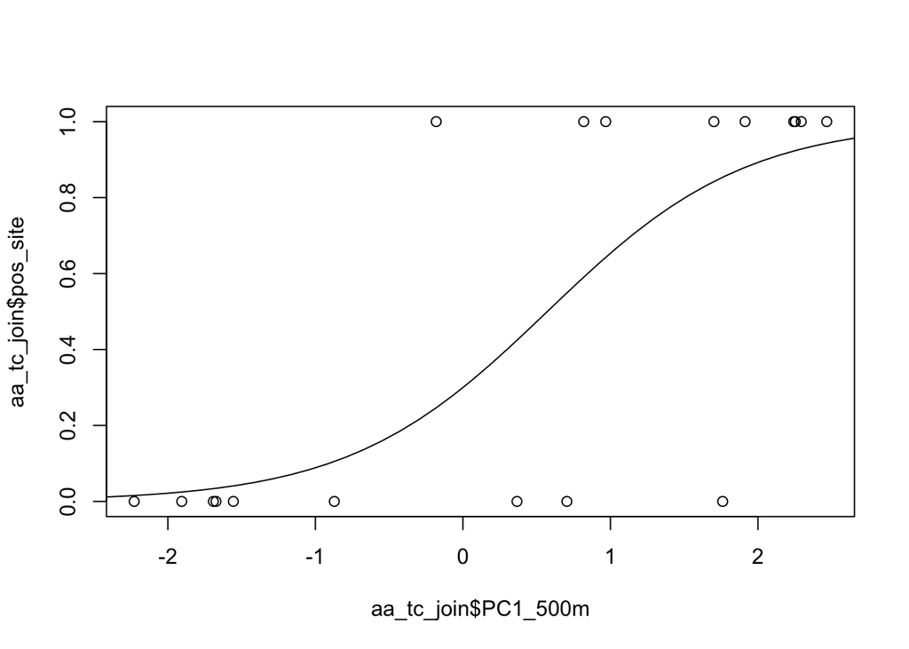

```r
mydata <- data.frame(PC1_500m = seq(-3,3, length = 50))
mydata$pred <- predict(P2, newdata = mydata, type = "response")
plot(x = aa_tc_join$PC1_500m, y = aa_tc_join$pos_site)
lines(mydata$PC1_500m, mydata$pred)
```